# Import modules

## Scatter Plot between Age and Target

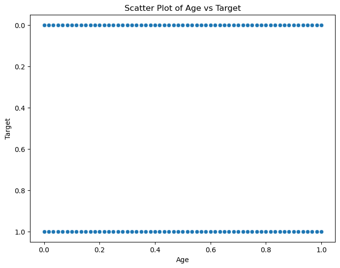

```python
# Scatter plot for age vs target
plt.figure(figsize=(8, 6))
sns.scatterplot(x='age', y='target', data=df)
plt.title('Scatter Plot of Age vs Target')
plt.xlabel('Age')
plt.ylabel('Target')
plt.show()
```

## Scatter Plot between Resting Blood Pressure and Target

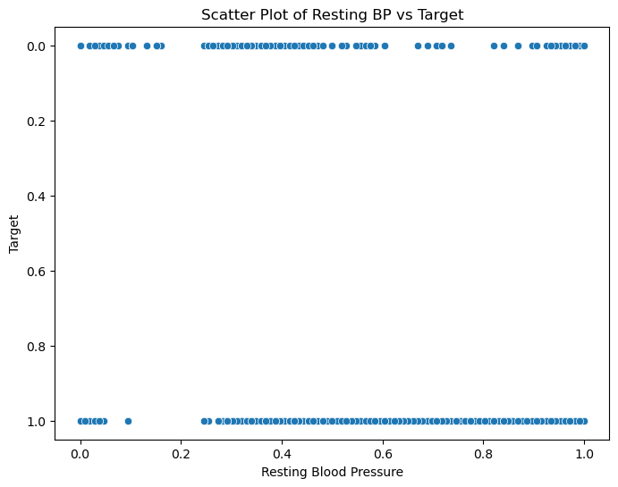

```python
# Scatter plot for restingBP vs target
plt.figure(figsize=(8, 6))
sns.scatterplot(x='restingBP', y='target', data=df)
plt.title('Scatter Plot of Resting BP vs Target')
plt.xlabel('Resting Blood Pressure')
plt.ylabel('Target')
plt.show()
```

## Scatter Plot between Serum Cholesterol and Target

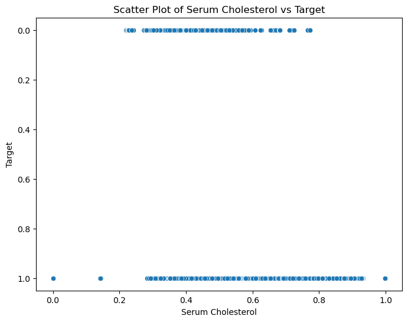

```python
# Scatter plot for serumcholestrol vs target
plt.figure(figsize=(8, 6))
sns.scatterplot(x='serumcholestrol', y='target', data=df)
plt.title('Scatter Plot of Serum Cholesterol vs Target')
plt.xlabel('Serum Cholesterol')
plt.ylabel('Target')
plt.show()
```

## Scatter Plot between Age vs Target (Categorized by Gender)

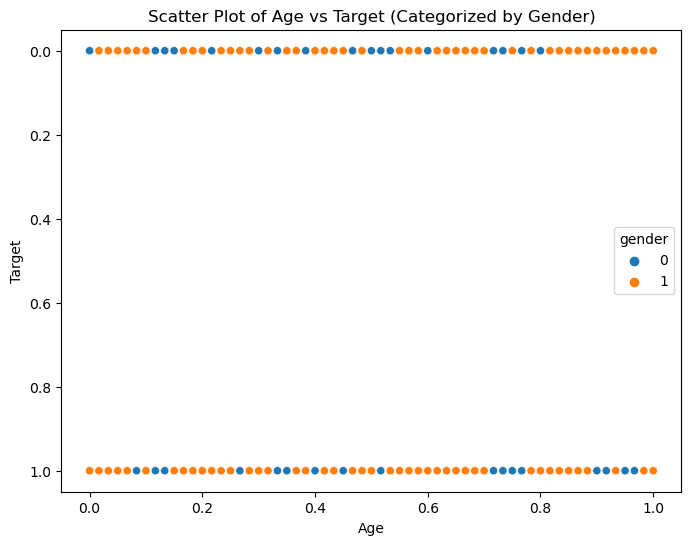

```python
# Scatter plot with hue (e.g., gender)
plt.figure(figsize=(8, 6))
sns.scatterplot(x='age', y='target', hue='gender', data=df)
plt.title('Scatter Plot of Age vs Target (Categorized by Gender)')
plt.xlabel('Age')
plt.ylabel('Target')
plt.show()
```

## Pair Plot (Pairwise relationships)

A matrix of scatter plots for all pairs of numerical variables.

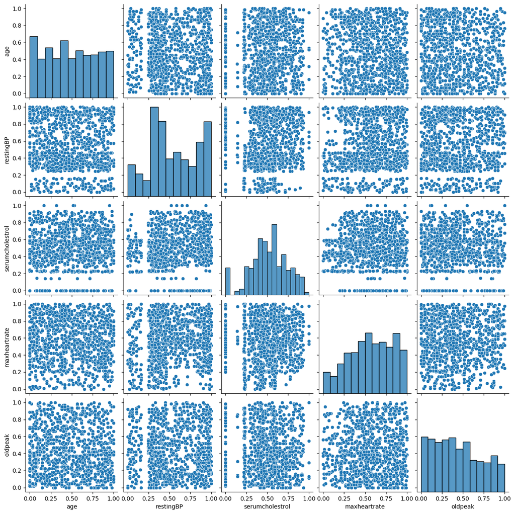

```python
sns.pairplot(df[['age', 'restingBP', 'serumcholestrol', 'maxheartrate', 'oldpeak', 'target']])
plt.show()
```

## FacetGrid (Pair of plots by a categorical variable)

### 1. age vs. serumcholestrol, split by target

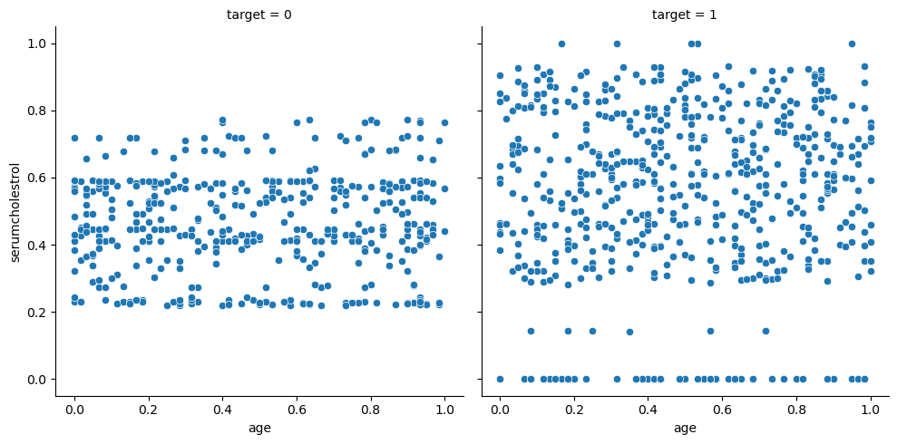

```python
g = sns.FacetGrid(df, col="target", height=5)
g.map(sns.scatterplot, "age", "serumcholestrol")
plt.show()
```

## Heatmap of Categorical Variables

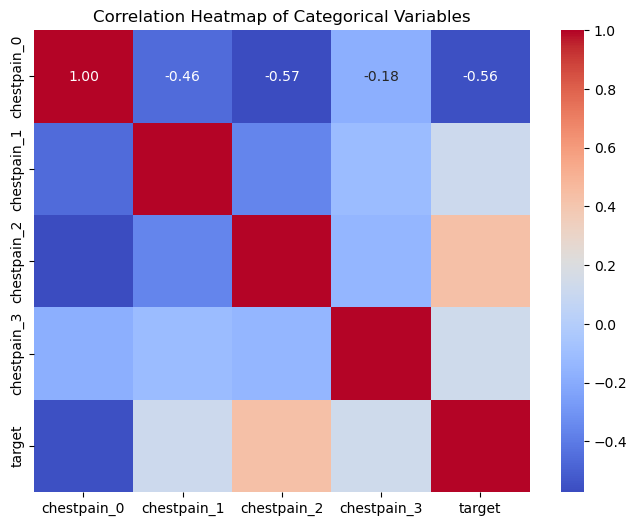

```python
# correlation between categorical variables like chestpain and target
cat_corr = df[['chestpain_0', 'chestpain_1', 'chestpain_2', 'chestpain_3', 'target']].corr()
plt.figure(figsize=(8, 6))
sns.heatmap(cat_corr, annot=True, cmap='coolwarm', fmt='.2f')
plt.title('Correlation Heatmap of Categorical Variables')
plt.show()
```

```
<function matplotlib.pyplot.ylabel(ylabel: 'str', fontdict: 'dict[str, Any] | None' = None, labelpad: 'float | None' = None, *, loc: "Literal['bottom', 'center', 'top'] | None" = None, **kwargs) -> 'Text'>
```

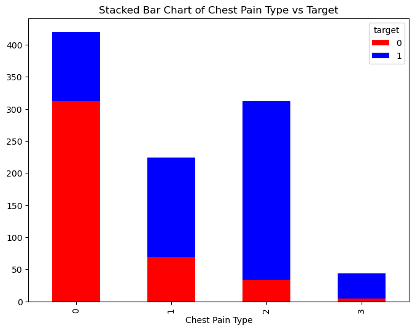

```python
# Stacked Bar Chart for chestpain types vs. target
cross_tab = pd.crosstab(df['chestpain'], df['target'])
cross_tab.plot(kind='bar', stacked=True, figsize=(8, 6), color=['red', 'blue'])
plt.title('Stacked Bar Chart of Chest Pain Type vs Target')
plt.xlabel('Chest Pain Type')
plt.ylabel
```

```python
print(df.dtypes)
```

```
age                   float64
gender               category
restingBP             float64
serumcholestrol       float64
fastingbloodsugar       int64
maxheartrate          float64
oldpeak               float64
noofmajorvessels      float64
target               category
chestpain_0             int64
chestpain_1             int64
chestpain_2             int64
chestpain_3             int64
restingrelectro_0       int64
restingrelectro_1       int64
restingrelectro_2       int64
slope_0                 int64
slope_1                 int64
slope_2                 int64
slope_3                 int64
chestpain               int64
restingrelectro         int64
slope                   int64
dtype: object
```

```python
# Convert 'gender' and 'target' columns to numeric
df['gender'] = pd.to_numeric(df['gender'], errors='coerce')
df['target'] = pd.to_numeric(df['target'], errors='coerce')
```

```python
print(df.dtypes)
```

```
age                  float64
gender                 int64
restingBP            float64
serumcholestrol      float64
fastingbloodsugar      int64
maxheartrate         float64
oldpeak              float64
noofmajorvessels     float64
target                 int64
chestpain_0            int64
chestpain_1            int64
chestpain_2            int64
chestpain_3            int64
restingrelectro_0      int64
restingrelectro_1      int64
restingrelectro_2      int64
slope_0                int64
slope_1                int64
slope_2                int64
slope_3                int64
chestpain              int64
restingrelectro        int64
slope                  int64
dtype: object
```

```python
df = df.drop(columns=['chestpain', 'restingrelectro', 'slope'])
```

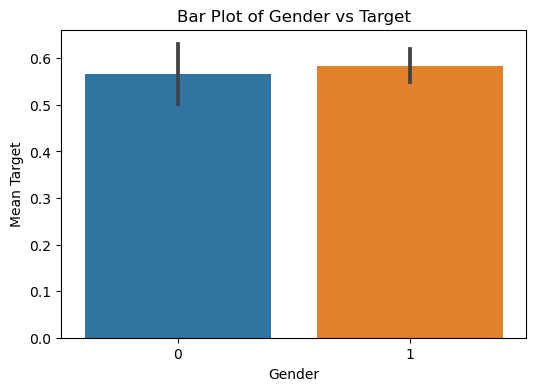

```python
plt.figure(figsize=(6, 4))
sns.barplot(x='gender', y='target', data=df)
plt.title('Bar Plot of Gender vs Target')
plt.xlabel('Gender')
plt.ylabel('Mean Target')
plt.show()
```

## Age vs. Max Heart Rate with Target Labels

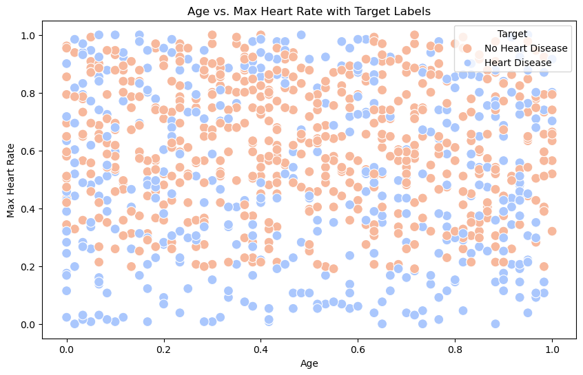

```python
plt.figure(figsize=(10, 6))
sns.scatterplot(x='age', y='maxheartrate', hue='target', data=df, palette='coolwarm', s=100)
plt.title('Age vs. Max Heart Rate with Target Labels')
plt.xlabel('Age')
plt.ylabel('Max Heart Rate')
plt.legend(title='Target', loc='upper right', labels=['No Heart Disease', 'Heart Disease'])
plt.show()
```

# Split the Data into Training and Testing Sets

```python
from sklearn.model_selection import train_test_split

# Features (X) and target (y)
X = df.drop(columns=['target'])  # Drop the target variable from features
y = df['target']  # Target variable

# Split the data into 80% training and 20% testing sets
X_train, X_test, y_train, y_test = train_test_split(X, y, test_size=0.2, random_state=42)
```

# Model Selection

1. Logistic Regression
2. Decision Tree
3. Random Forest
4. Support Vector Machine (SVM)
5. K-Nearest Neighbors (KNN)
6. Gradient Boosting (e.g., XGBoost)

```python
from sklearn.linear_model import LogisticRegression
from sklearn.tree import DecisionTreeClassifier
from sklearn.ensemble import RandomForestClassifier
from sklearn.svm import SVC
from sklearn.neighbors import KNeighborsClassifier
from sklearn.ensemble import GradientBoostingClassifier

# Initialize models
logreg = LogisticRegression()
dtree = DecisionTreeClassifier()
rf = RandomForestClassifier()
svm = SVC()
knn = KNeighborsClassifier()
gb = GradientBoostingClassifier()

# List of models to evaluate
models = [logreg, dtree, rf, svm, knn, gb]
```

# Train the Models

Each model will be trained on the training data

```python
# Train each model on the training set
for model in models:
    model.fit(X_train, y_train)
```

# Evaluate the Models

Now that the models are trained, we can evaluate them using various metrics such as accuracy, precision, recall, F1-score, and ROC AUC score.

We'll use cross-validation and confusion matrices to get a better understanding of the models' performance.

```python
from sklearn.metrics import accuracy_score, confusion_matrix, classification_report

# Evaluate the models on the testing set
for model in models:
    y_pred = model.predict(X_test)
    print(f"Model: {model.__class__.__name__}")
    print(f"Accuracy: {accuracy_score(y_test, y_pred):.4f}")
    print(f"Confusion Matrix:\n{confusion_matrix(y_test, y_pred)}")
    print(f"Classification Report:\n{classification_report(y_test, y_pred)}")
    print("\n" + "-"*50 + "\n")
```

```
Model: LogisticRegression
Accuracy: 0.9700
Confusion Matrix:
[[ 81   2]
 [  4 113]]
Classification Report:
              precision    recall  f1-score   support

           0       0.95      0.98      0.96        83
           1       0.98      0.97      0.97       117

    accuracy                           0.97       200
   macro avg       0.97      0.97      0.97       200
weighted avg       0.97      0.97      0.97       200


--------------------------------------------------

Model: DecisionTreeClassifier
Accuracy: 0.9750
Confusion Matrix:
[[ 79   4]
 [  1 116]]
Classification Report:
              precision    recall  f1-score   support

           0       0.99      0.95      0.97        83
           1       0.97      0.99      0.98       117

    accuracy                           0.97       200
   macro avg       0.98      0.97      0.97       200
weighted avg       0.98      0.97      0.97       200


--------------------------------------------------

Model: RandomForestClassifier
Accuracy: 0.9850
Confusion Matrix:
[[ 81   2]
```

[output cut: 52 more lines]

```
Confusion Matrix:
[[ 82   1]
 [  0 117]]
Classification Report:
              precision    recall  f1-score   support

           0       1.00      0.99      0.99        83
           1       0.99      1.00      1.00       117

    accuracy                           0.99       200
   macro avg       1.00      0.99      0.99       200
weighted avg       1.00      0.99      0.99       200


--------------------------------------------------
```

# Hyperparameter Tuning

### 1. Logistic Regression Hyperparameter Tuning and Evaluation

```
Fitting 5 folds for each of 30 candidates, totalling 150 fits
Best Hyperparameters for Logistic Regression: {'C': 10, 'penalty': 'l2', 'solver': 'lbfgs'}
Best Cross-Validation Score for Logistic Regression: 0.9675
Logistic Regression Test Accuracy: 0.9650
Logistic Regression Classification Report:
              precision    recall  f1-score   support

           0       0.96      0.95      0.96        83
           1       0.97      0.97      0.97       117

    accuracy                           0.96       200
   macro avg       0.96      0.96      0.96       200
weighted avg       0.96      0.96      0.96       200
```

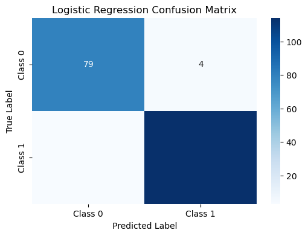

```
Logistic Regression ROC-AUC Score: 0.9975
```

```python
from sklearn.linear_model import LogisticRegression
from sklearn.model_selection import GridSearchCV
from sklearn.metrics import accuracy_score, classification_report, confusion_matrix, roc_auc_score
import seaborn as sns
import matplotlib.pyplot as plt

# Initialize Logistic Regression model
log_reg = LogisticRegression(max_iter=1000)

# Define hyperparameter grid for Logistic Regression
param_grid_log_reg = {
    'C': [0.01, 0.1, 1, 10, 100],
    'solver': ['lbfgs', 'liblinear', 'saga'],
    'penalty': ['l2', 'none']
}

# Initialize GridSearchCV
grid_search_log_reg = GridSearchCV(estimator=log_reg, param_grid=param_grid_log_reg, cv=5, n_jobs=-1, verbose=2)

# Fit the model
grid_search_log_reg.fit(X_train, y_train)

# Best Hyperparameters and Performance
print(f"Best Hyperparameters for Logistic Regression: {grid_search_log_reg.best_params_}")
print(f"Best Cross-Validation Score for Logistic Regression: {grid_search_log_reg.best_score_:.4f}")

# Predictions and Evaluation
y_pred_log_reg = grid_search_log_reg.best_estimator_.predict(X_test)

# Accuracy
lr_accuracy = accuracy_score(y_test, y_pred_log_reg)
print(f"Logistic Regression Test Accuracy: {lr_accuracy:.4f}")

# Classification Report
print("Logistic Regression Classification Report:")
print(classification_report(y_test, y_pred_log_reg))

# Confusion Matrix
conf_matrix_log_reg = confusion_matrix(y_test, y_pred_log_reg)
plt.figure(figsize=(6, 4))
sns.heatmap(conf_matrix_log_reg, annot=True, fmt='d', cmap='Blues', xticklabels=['Class 0', 'Class 1'], yticklabels=['Class 0', 'Class 1'])
plt.title("Logistic Regression Confusion Matrix")
plt.xlabel("Predicted Label")
plt.ylabel("True Label")
plt.show()

# ROC-AUC Score
roc_auc_log_reg = roc_auc_score(y_test, grid_search_log_reg.best_estimator_.predict_proba(X_test)[:, 1])
print(f"Logistic Regression ROC-AUC Score: {roc_auc_log_reg:.4f}")
```

### 2. Decision Tree Hyperparameter Tuning and Evaluation

```
Fitting 5 folds for each of 72 candidates, totalling 360 fits
Best Hyperparameters for Decision Tree: {'criterion': 'entropy', 'max_depth': None, 'min_samples_leaf': 2, 'min_samples_split': 10}
Best Cross-Validation Score for Decision Tree: 0.9762
Decision Tree Test Accuracy: 0.9550
Decision Tree Classification Report:
              precision    recall  f1-score   support

           0       0.93      0.96      0.95        83
           1       0.97      0.95      0.96       117

    accuracy                           0.95       200
   macro avg       0.95      0.96      0.95       200
weighted avg       0.96      0.95      0.96       200
```

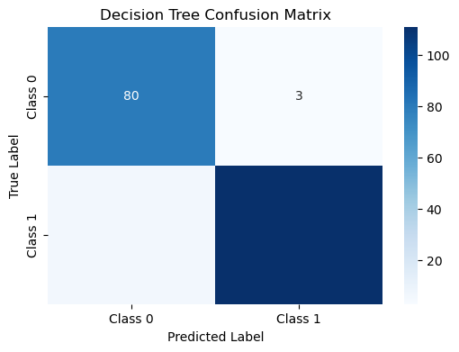

```
Decision Tree ROC-AUC Score: 0.9734
```

```python
from sklearn.tree import DecisionTreeClassifier

# Initialize Decision Tree model
dt = DecisionTreeClassifier()

# Define hyperparameter grid for Decision Tree
param_grid_dt = {
    'criterion': ['gini', 'entropy'],
    'max_depth': [None, 10, 20, 30],
    'min_samples_split': [2, 5, 10],
    'min_samples_leaf': [1, 2, 4]
}

# Initialize GridSearchCV
grid_search_dt = GridSearchCV(estimator=dt, param_grid=param_grid_dt, cv=5, n_jobs=-1, verbose=2)

# Fit the model
grid_search_dt.fit(X_train, y_train)

# Best Hyperparameters and Performance
print(f"Best Hyperparameters for Decision Tree: {grid_search_dt.best_params_}")
print(f"Best Cross-Validation Score for Decision Tree: {grid_search_dt.best_score_:.4f}")

# Predictions and Evaluation
y_pred_dt = grid_search_dt.best_estimator_.predict(X_test)

# Accuracy
dt_accuracy = accuracy_score(y_test, y_pred_dt)
print(f"Decision Tree Test Accuracy: {dt_accuracy:.4f}")

# Classification Report
print("Decision Tree Classification Report:")
print(classification_report(y_test, y_pred_dt))

# Confusion Matrix
conf_matrix_dt = confusion_matrix(y_test, y_pred_dt)
plt.figure(figsize=(6, 4))
sns.heatmap(conf_matrix_dt, annot=True, fmt='d', cmap='Blues', xticklabels=['Class 0', 'Class 1'], yticklabels=['Class 0', 'Class 1'])
plt.title("Decision Tree Confusion Matrix")
plt.xlabel("Predicted Label")
plt.ylabel("True Label")
plt.show()

# ROC-AUC Score
roc_auc_dt = roc_auc_score(y_test, grid_search_dt.best_estimator_.predict_proba(X_test)[:, 1])
print(f"Decision Tree ROC-AUC Score: {roc_auc_dt:.4f}")
```

### 3. Random Forest Hyperparameter Tuning and Evaluation

```
Fitting 5 folds for each of 216 candidates, totalling 1080 fits
Best Hyperparameters for Random Forest: {'bootstrap': False, 'max_depth': 10, 'min_samples_leaf': 1, 'min_samples_split': 5, 'n_estimators': 300}
Best Cross-Validation Score for Random Forest: 0.9800
Random Forest Test Accuracy: 0.9850
Random Forest Classification Report:
              precision    recall  f1-score   support

           0       0.99      0.98      0.98        83
           1       0.98      0.99      0.99       117

    accuracy                           0.98       200
   macro avg       0.99      0.98      0.98       200
weighted avg       0.99      0.98      0.98       200
```

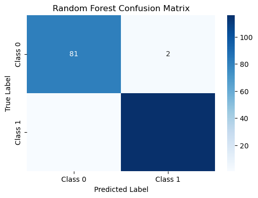

```
Random Forest ROC-AUC Score: 0.9995
```

```python
from sklearn.ensemble import RandomForestClassifier

# Initialize Random Forest model
rf = RandomForestClassifier()

# Define hyperparameter grid for Random Forest
param_grid_rf = {
    'n_estimators': [100, 200, 300],
    'max_depth': [None, 10, 20, 30],
    'min_samples_split': [2, 5, 10],
    'min_samples_leaf': [1, 2, 4],
    'bootstrap': [True, False]
}

# Initialize GridSearchCV
grid_search_rf = GridSearchCV(estimator=rf, param_grid=param_grid_rf, cv=5, n_jobs=-1, verbose=2)

# Fit the model
grid_search_rf.fit(X_train, y_train)

# Best Hyperparameters and Performance
print(f"Best Hyperparameters for Random Forest: {grid_search_rf.best_params_}")
print(f"Best Cross-Validation Score for Random Forest: {grid_search_rf.best_score_:.4f}")

# Predictions and Evaluation
y_pred_rf = grid_search_rf.best_estimator_.predict(X_test)

# Accuracy
rf_accuracy = accuracy_score(y_test, y_pred_rf)
print(f"Random Forest Test Accuracy: {rf_accuracy:.4f}")

# Classification Report
print("Random Forest Classification Report:")
print(classification_report(y_test, y_pred_rf))

# Confusion Matrix
conf_matrix_rf = confusion_matrix(y_test, y_pred_rf)
plt.figure(figsize=(6, 4))
sns.heatmap(conf_matrix_rf, annot=True, fmt='d', cmap='Blues', xticklabels=['Class 0', 'Class 1'], yticklabels=['Class 0', 'Class 1'])
plt.title("Random Forest Confusion Matrix")
plt.xlabel("Predicted Label")
plt.ylabel("True Label")
plt.show()

# ROC-AUC Score
roc_auc_rf = roc_auc_score(y_test, grid_search_rf.best_estimator_.predict_proba(X_test)[:, 1])
print(f"Random Forest ROC-AUC Score: {roc_auc_rf:.4f}")
```

### 4. Support Vector Machine (SVM) Hyperparameter Tuning and Evaluation

```
Fitting 5 folds for each of 24 candidates, totalling 120 fits
Best Hyperparameters for SVM: {'C': 10, 'gamma': 'scale', 'kernel': 'linear'}
Best Cross-Validation Score for SVM: 0.9650
SVM Test Accuracy: 0.9700
SVM Classification Report:
              precision    recall  f1-score   support

           0       0.98      0.95      0.96        83
           1       0.97      0.98      0.97       117

    accuracy                           0.97       200
   macro avg       0.97      0.97      0.97       200
weighted avg       0.97      0.97      0.97       200
```

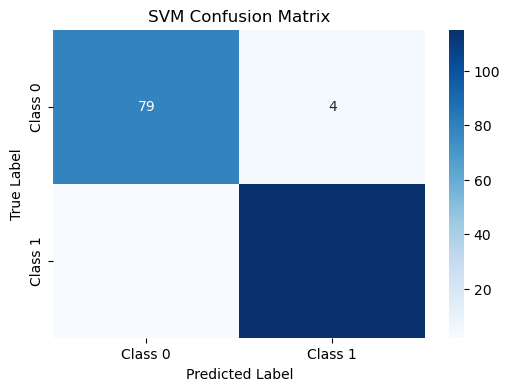

```
SVM ROC-AUC Score: 0.9968
```

```python
from sklearn.svm import SVC

# Initialize SVM model
svm = SVC(probability=True)

# Define hyperparameter grid for SVM
param_grid_svm = {
    'C': [0.01, 0.1, 1, 10],
    'kernel': ['linear', 'rbf', 'poly'],
    'gamma': ['scale', 'auto']
}

# Initialize GridSearchCV
grid_search_svm = GridSearchCV(estimator=svm, param_grid=param_grid_svm, cv=5, n_jobs=-1, verbose=2)

# Fit the model
grid_search_svm.fit(X_train, y_train)

# Best Hyperparameters and Performance
print(f"Best Hyperparameters for SVM: {grid_search_svm.best_params_}")
print(f"Best Cross-Validation Score for SVM: {grid_search_svm.best_score_:.4f}")

# Predictions and Evaluation
y_pred_svm = grid_search_svm.best_estimator_.predict(X_test)

# Accuracy
svm_accuracy = accuracy_score(y_test, y_pred_svm)
print(f"SVM Test Accuracy: {svm_accuracy:.4f}")

# Classification Report
print("SVM Classification Report:")
print(classification_report(y_test, y_pred_svm))

# Confusion Matrix
conf_matrix_svm = confusion_matrix(y_test, y_pred_svm)
plt.figure(figsize=(6, 4))
sns.heatmap(conf_matrix_svm, annot=True, fmt='d', cmap='Blues', xticklabels=['Class 0', 'Class 1'], yticklabels=['Class 0', 'Class 1'])
plt.title("SVM Confusion Matrix")
plt.xlabel("Predicted Label")
plt.ylabel("True Label")
plt.show()

# ROC-AUC Score
roc_auc_svm = roc_auc_score(y_test, grid_search_svm.best_estimator_.predict_proba(X_test)[:, 1])
print(f"SVM ROC-AUC Score: {roc_auc_svm:.4f}")
```

### 5. K-Nearest Neighbors (KNN) Hyperparameter Tuning and Evaluation

```
Fitting 5 folds for each of 30 candidates, totalling 150 fits
Best Hyperparameters for KNN: {'metric': 'manhattan', 'n_neighbors': 3, 'weights': 'distance'}
Best Cross-Validation Score for KNN: 0.9575
KNN Test Accuracy: 0.9750
KNN Classification Report:
              precision    recall  f1-score   support

           0       0.99      0.95      0.97        83
           1       0.97      0.99      0.98       117

    accuracy                           0.97       200
   macro avg       0.98      0.97      0.97       200
weighted avg       0.98      0.97      0.97       200
```

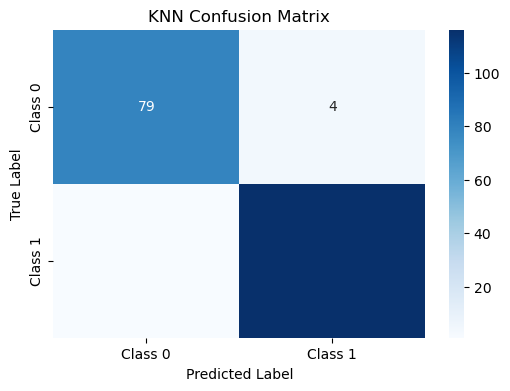

```
KNN ROC-AUC Score: 0.9982
```

```python
from sklearn.neighbors import KNeighborsClassifier

# Initialize KNN model
knn = KNeighborsClassifier()

# Define hyperparameter grid for KNN
param_grid_knn = {
    'n_neighbors': [3, 5, 7, 9, 11],
    'weights': ['uniform', 'distance'],
    'metric': ['euclidean', 'manhattan', 'minkowski']
}

# Initialize GridSearchCV
grid_search_knn = GridSearchCV(estimator=knn, param_grid=param_grid_knn, cv=5, n_jobs=-1, verbose=2)

# Fit the model
grid_search_knn.fit(X_train, y_train)

# Best Hyperparameters and Performance
print(f"Best Hyperparameters for KNN: {grid_search_knn.best_params_}")
print(f"Best Cross-Validation Score for KNN: {grid_search_knn.best_score_:.4f}")

# Predictions and Evaluation
y_pred_knn = grid_search_knn.best_estimator_.predict(X_test)

# Accuracy
knn_accuracy = accuracy_score(y_test, y_pred_knn)
print(f"KNN Test Accuracy: {knn_accuracy:.4f}")

# Classification Report
print("KNN Classification Report:")
print(classification_report(y_test, y_pred_knn))

# Confusion Matrix
conf_matrix_knn = confusion_matrix(y_test, y_pred_knn)
plt.figure(figsize=(6, 4))
sns.heatmap(conf_matrix_knn, annot=True, fmt='d', cmap='Blues', xticklabels=['Class 0', 'Class 1'], yticklabels=['Class 0', 'Class 1'])
plt.title("KNN Confusion Matrix")
plt.xlabel("Predicted Label")
plt.ylabel("True Label")
plt.show()

# ROC-AUC Score
roc_auc_knn = roc_auc_score(y_test, grid_search_knn.best_estimator_.predict_proba(X_test)[:, 1])
print(f"KNN ROC-AUC Score: {roc_auc_knn:.4f}")
```

### 6. Gradient Boosting (e.g., XGBoost) Hyperparameter Tuning and Evaluation

```
Fitting 5 folds for each of 243 candidates, totalling 1215 fits
Best Hyperparameters for XGBoost: {'colsample_bytree': 0.8, 'learning_rate': 0.1, 'max_depth': 3, 'n_estimators': 200, 'subsample': 1.0}
Best Cross-Validation Score for XGBoost: 0.9788
XGBoost Test Accuracy: 0.9900
XGBoost Classification Report:
              precision    recall  f1-score   support

           0       0.99      0.99      0.99        83
           1       0.99      0.99      0.99       117

    accuracy                           0.99       200
   macro avg       0.99      0.99      0.99       200
weighted avg       0.99      0.99      0.99       200
```

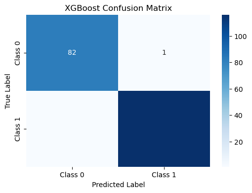

```
XGBoost ROC-AUC Score: 0.9997
```

```python
from xgboost import XGBClassifier
from sklearn.metrics import accuracy_score, classification_report, confusion_matrix, roc_auc_score
import seaborn as sns
import matplotlib.pyplot as plt

# Initialize XGBoost model
xgb = XGBClassifier()

# Define hyperparameter grid for XGBoost
param_grid_xgb = {
    'n_estimators': [100, 200, 300],
    'learning_rate': [0.01, 0.1, 0.2],
    'max_depth': [3, 5, 7],
    'subsample': [0.8, 0.9, 1.0],
    'colsample_bytree': [0.8, 0.9, 1.0]
}

# Initialize GridSearchCV
grid_search_xgb = GridSearchCV(estimator=xgb, param_grid=param_grid_xgb, cv=5, n_jobs=-1, verbose=2)

# Fit the model
grid_search_xgb.fit(X_train, y_train)

# Best Hyperparameters and Performance
print(f"Best Hyperparameters for XGBoost: {grid_search_xgb.best_params_}")
print(f"Best Cross-Validation Score for XGBoost: {grid_search_xgb.best_score_:.4f}")

# Predictions and Evaluation
y_pred_xgb = grid_search_xgb.best_estimator_.predict(X_test)

# Accuracy
xgb_accuracy = accuracy_score(y_test, y_pred_xgb)
print(f"XGBoost Test Accuracy: {xgb_accuracy:.4f}")

# Classification Report
print("XGBoost Classification Report:")
print(classification_report(y_test, y_pred_xgb))

# Confusion Matrix
conf_matrix_xgb = confusion_matrix(y_test, y_pred_xgb)
plt.figure(figsize=(6, 4))
sns.heatmap(conf_matrix_xgb, annot=True, fmt='d', cmap='Blues', xticklabels=['Class 0', 'Class 1'], yticklabels=['Class 0', 'Class 1'])
plt.title("XGBoost Confusion Matrix")
plt.xlabel("Predicted Label")
plt.ylabel("True Label")
plt.show()

# ROC-AUC Score
roc_auc_xgb = roc_auc_score(y_test, grid_search_xgb.best_estimator_.predict_proba(X_test)[:, 1])
print(f"XGBoost ROC-AUC Score: {roc_auc_xgb:.4f}")
```

### 7. Gaussian Naive Bayes (GaussianNB) hyperparameter tuning and evaluation

```
Fitting 5 folds for each of 5 candidates, totalling 25 fits
Best Hyperparameters for GaussianNB: {'var_smoothing': 1e-09}
Best Cross-Validation Score for GaussianNB: 0.9412
GaussianNB Test Accuracy: 0.9750
GaussianNB Classification Report:
              precision    recall  f1-score   support

           0       0.98      0.96      0.97        83
           1       0.97      0.98      0.98       117

    accuracy                           0.97       200
   macro avg       0.98      0.97      0.97       200
weighted avg       0.98      0.97      0.97       200
```

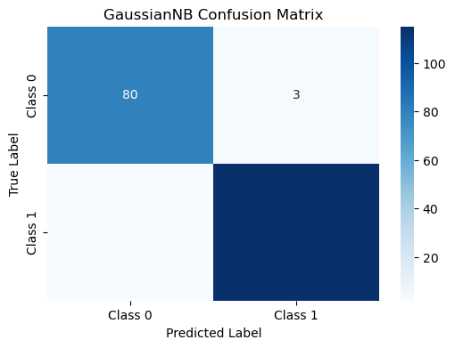

```
GaussianNB ROC-AUC Score: 0.9976
```

```python
from sklearn.naive_bayes import GaussianNB
from sklearn.model_selection import GridSearchCV
from sklearn.metrics import accuracy_score, classification_report, confusion_matrix, roc_auc_score
import seaborn as sns
import matplotlib.pyplot as plt

# Initialize GaussianNB model
gnb = GaussianNB()

# Define hyperparameter grid for Gaussian Naive Bayes
param_grid_gnb = {
    'var_smoothing': [1e-9, 1e-8, 1e-7, 1e-6, 1e-5]  # Regularization parameter to prevent division by zero
}

# Initialize GridSearchCV for GaussianNB
grid_search_gnb = GridSearchCV(estimator=gnb, param_grid=param_grid_gnb, cv=5, n_jobs=-1, verbose=2)

# Fit the model
grid_search_gnb.fit(X_train, y_train)

# Best Hyperparameters and Performance
print(f"Best Hyperparameters for GaussianNB: {grid_search_gnb.best_params_}")
print(f"Best Cross-Validation Score for GaussianNB: {grid_search_gnb.best_score_:.4f}")

# Predictions and Evaluation
y_pred_gnb = grid_search_gnb.best_estimator_.predict(X_test)

# Accuracy
gnb_accuracy = accuracy_score(y_test, y_pred_gnb)
print(f"GaussianNB Test Accuracy: {gnb_accuracy:.4f}")

# Classification Report
print("GaussianNB Classification Report:")
print(classification_report(y_test, y_pred_gnb))

# Confusion Matrix
conf_matrix_gnb = confusion_matrix(y_test, y_pred_gnb)
plt.figure(figsize=(6, 4))
sns.heatmap(conf_matrix_gnb, annot=True, fmt='d', cmap='Blues', xticklabels=['Class 0', 'Class 1'], yticklabels=['Class 0', 'Class 1'])
plt.title("GaussianNB Confusion Matrix")
plt.xlabel("Predicted Label")
plt.ylabel("True Label")
plt.show()

# ROC-AUC Score
roc_auc_gnb = roc_auc_score(y_test, grid_search_gnb.best_estimator_.predict_proba(X_test)[:, 1])
print(f"GaussianNB ROC-AUC Score: {roc_auc_gnb:.4f}")
```

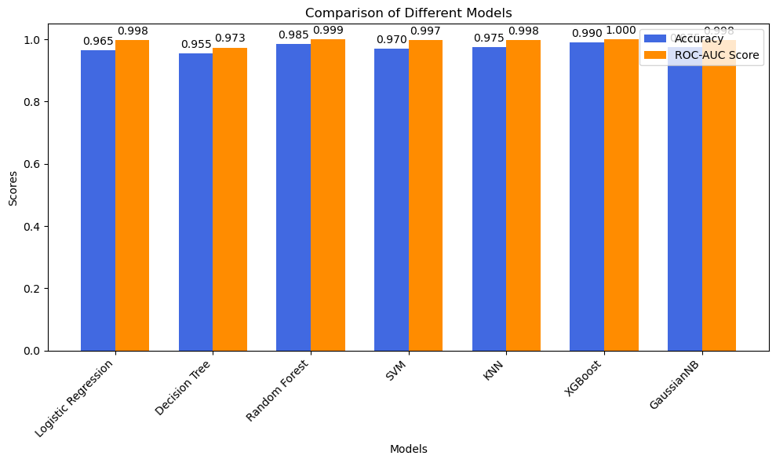

```python
# List of models and their corresponding accuracy or ROC-AUC scores
models = ['Logistic Regression', 'Decision Tree', 'Random Forest', 'SVM', 'KNN', 'XGBoost', 'GaussianNB']
accuracy_scores = [lr_accuracy, dt_accuracy, rf_accuracy, svm_accuracy, knn_accuracy, xgb_accuracy, gnb_accuracy]
roc_auc_scores = [roc_auc_log_reg, roc_auc_dt, roc_auc_rf, roc_auc_svm, roc_auc_knn, roc_auc_xgb, roc_auc_gnb]

# Create a bar plot for accuracy comparison
x = np.arange(len(models))  # Position of the bars
width = 0.35  # Width of the bars

fig, ax = plt.subplots(figsize=(10, 6))

# Bar chart for accuracy
bars1 = ax.bar(x - width/2, accuracy_scores, width, label='Accuracy', color='royalblue')

# Bar chart for ROC-AUC scores
bars2 = ax.bar(x + width/2, roc_auc_scores, width, label='ROC-AUC Score', color='darkorange')

# Add some text for labels, title, and custom x-axis tick labels
ax.set_xlabel('Models')
ax.set_ylabel('Scores')
ax.set_title('Comparison of Different Models')
ax.set_xticks(x)
ax.set_xticklabels(models, rotation=45, ha='right')
ax.legend()

# Add values on top of bars
def add_labels(bars, scores):
    for bar, score in zip(bars, scores):
        height = bar.get_height()
        ax.annotate(f'{score:.3f}',
                    xy=(bar.get_x() + bar.get_width() / 2, height),
                    xytext=(0, 3),  # 3 points vertical offset
                    textcoords="offset points",
                    ha='center', va='bottom')

add_labels(bars1, accuracy_scores)
add_labels(bars2, roc_auc_scores)

# Show plot
plt.tight_layout()
plt.show()
```

**Conclusion**

- XGBoost is the best-performing model in both accuracy and ROC-AUC score, making it the top choice for this task.
- Random Forest, KNN, and SVM also perform well, though slightly behind XGBoost.
- Logistic Regression has a high ROC-AUC but lower accuracy, which suggests it's good for distinguishing between classes but might not be as precise in predictions as some other models.
- Decision Tree performs the worst among the compared models, with both lower accuracy and ROC-AUC, indicating it may require additional tuning or may not be the best fit for this task.

Thus, based on the chart, XGBoost is recommended as the final model for this cardiovascular disease prediction project.

# Final modeling using XGBoost

```python
# final model
import xgboost as xgb

xgb_model = xgb.XGBClassifier(
    colsample_bytree=0.8,
    learning_rate=0.1,
    max_depth=3,
    n_estimators=200,
    subsample=1.0,
    random_state=42
)

xgb_model.fit(X, y)
```

```
XGBClassifier(base_score=None, booster=None, callbacks=None,
              colsample_bylevel=None, colsample_bynode=None,
              colsample_bytree=0.8, device=None, early_stopping_rounds=None,
              enable_categorical=False, eval_metric=None, feature_types=None,
              gamma=None, grow_policy=None, importance_type=None,
              interaction_constraints=None, learning_rate=0.1, max_bin=None,
              max_cat_threshold=None, max_cat_to_onehot=None,
              max_delta_step=None, max_depth=3, max_leaves=None,
              min_child_weight=None, missing=nan, monotone_constraints=None,
              multi_strategy=None, n_estimators=200, n_jobs=None,
              num_parallel_tree=None, random_state=42, ...)
```

# Pickle the Final Model

```python
import pickle

# Save the model to a file
with open('xgboost_model.pkl', 'wb') as file:
    pickle.dump(xgb_model, file)

print("Model saved successfully!")
```

```
Model saved successfully!
```

# Checking the impact of Age and Gender features on model accuracy

```
Accuracy with Age and Gender:  0.985
Classification Report with Age and Gender:
               precision    recall  f1-score   support

           0       0.98      0.99      0.98        83
           1       0.99      0.98      0.99       117

    accuracy                           0.98       200
   macro avg       0.98      0.99      0.98       200
weighted avg       0.99      0.98      0.99       200

ROC-AUC Score with Age and Gender:  0.9854288950674492
```

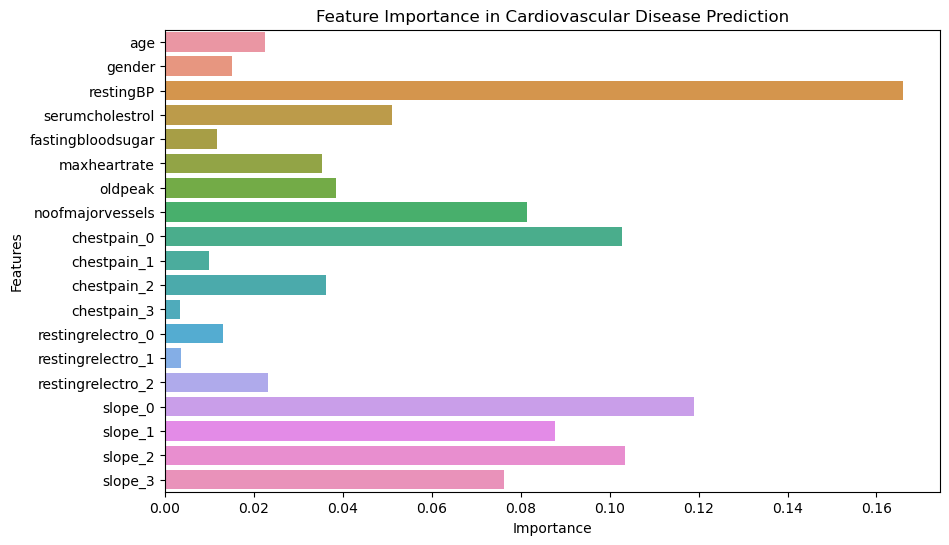

```
Accuracy without Age and Gender:  0.97
Classification Report without Age and Gender:
               precision    recall  f1-score   support

           0       0.98      0.95      0.96        83
           1       0.97      0.98      0.97       117

    accuracy                           0.97       200
   macro avg       0.97      0.97      0.97       200
weighted avg       0.97      0.97      0.97       200

ROC-AUC Score without Age and Gender:  0.9673566059108227
```

```python
from sklearn.metrics import accuracy_score, classification_report, roc_auc_score

# Train a Random Forest Classifier
model = RandomForestClassifier(random_state=42)
model.fit(X_train, y_train)

# Make predictions
y_pred = model.predict(X_test)

# Evaluate model performance
print("Accuracy with Age and Gender: ", accuracy_score(y_test, y_pred))
print("Classification Report with Age and Gender:\n", classification_report(y_test, y_pred))
print("ROC-AUC Score with Age and Gender: ", roc_auc_score(y_test, y_pred))

# Feature Importance: Assess the impact of age and gender
importances = model.feature_importances_
features = X.columns

# Plot the feature importance
plt.figure(figsize=(10, 6))
sns.barplot(x=importances, y=features)
plt.title('Feature Importance in Cardiovascular Disease Prediction')
plt.xlabel('Importance')
plt.ylabel('Features')
plt.show()

# To show how age and gender impact predictions:
# 1. Evaluate with and without age and gender
X_without_age_gender = X.drop(columns=['age', 'gender'])  # Dropping age and gender
X_train_no_age_gender, X_test_no_age_gender = X_without_age_gender.loc[X_train.index], X_without_age_gender.loc[X_test.index]

# Train model without age and gender
model_no_age_gender = RandomForestClassifier(random_state=42)
model_no_age_gender.fit(X_train_no_age_gender, y_train)

# Make predictions
y_pred_no_age_gender = model_no_age_gender.predict(X_test_no_age_gender)

# Evaluate model without age and gender
print("Accuracy without Age and Gender: ", accuracy_score(y_test, y_pred_no_age_gender))
print("Classification Report without Age and Gender:\n", classification_report(y_test, y_pred_no_age_gender))
print("ROC-AUC Score without Age and Gender: ", roc_auc_score(y_test, y_pred_no_age_gender))

# Compare the performance:
# If the model performs significantly worse without age and gender, this indicates that they are important factors.
```

# Final Conclusion

Based on the results of the model evaluation with and without age and gender, we can draw the following conclusions:

Model Performance with Age and Gender:

- The model achieves an accuracy of 98.5% when both age and gender are included as features.
- The ROC-AUC score is 0.985, indicating excellent model performance in distinguishing between positive and negative cases of cardiovascular disease.
- The classification report shows that the model performs well across both classes (0 and 1), with precision, recall, and F1-score values all near 1, indicating that both false positives and false negatives are minimized.

Model Performance without Age and Gender:

- The model's accuracy drops to 97% when age and gender are excluded from the feature set.
- The ROC-AUC score decreases to 0.967, showing a slight reduction in the model's ability to distinguish between positive and negative cases.
- The classification report still shows good performance, but the recall for class 0 (non-cardiovascular disease) drops to 0.95, indicating that the model is less effective at correctly predicting this class without age and gender as features.

Conclusion: